# Domino Arithmetic

## What is a Domino?

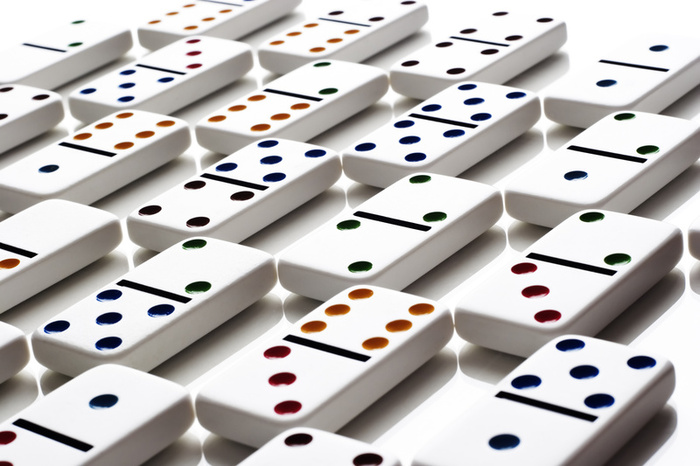

## What is a Domino?

For our purposes, a domino is a 2 x 1 rectangle:

[interactive chart not shown]

- Numbers on the dominos don’t matter
- Arithmetic will be about something else (stay tuned)

## Problem of the day

### Q. How many wanys can we tile a 3 \(\times\) n rectangle with 2 \(\times\) 1 dominoes?

#### **Rules**

- no overlap
- no gaps

#### **Notation**

- u(n) = number of ways to tile a 3 \(\times\) n rectangle
- U(n) = listing of all tilings of a 3 \(\times\) n rectangle
- u(n) = |U(n)|

### **Example:** What is u(2)? What is U(2)?

## u(2) = 3

Here’s U(2):

[interactive chart not shown]

## u(2) = 3

Here’s U(2):

[interactive chart not shown]

### How do we know there aren’t any more?

- “I couldn’t find any more” is not an acceptable answer.

## Your Turn

How much of this table can you fill out?

| n | u(n) | U(n) |
| --- | --- | --- |
| 1 | ? | ? |
| 2 | ? | ? |
| 3 | ? | ? |
| 4 | ? | ? |
| 5 | ? | ? |

| n | u(n) | U(n) |
| --- | --- | --- |
| 6 | ? | ? |
| 7 | ? | ? |
| 8 | ? | ? |
| 9 | ? | ? |
| 10 | ? | ? |

## Which values of u(n) are easy?

## Which values of u(n) are easy?

If n is odd, then u(n) = 0.

- Area of 3 \(\times\) n rectangle is 3n, which is odd when n is **odd**.
- Area covered by dominos is 2d (d = number of dominos), which is **even**.
- So it isn’t possible to tile a 3 \(\times\) n rectangle with dominos.

## What is u(4)?

## What is u(4)?

### **u(4) = 11**

[interactive chart not shown]

### **u(6) = ??**

### **u(8) = ??**

## Filling out the table

| u(0) | u(1) | u(2) | u(3) | u(4) | u(5) | u(6) | u(7) | u(8) |
| --- | --- | --- | --- | --- | --- | --- | --- | --- |
| 1 | 0 | 3 | 0 | 11 | 0 | ? | 0 | ? |

These get hard fast… We need some help.

## Help!

To solve this problem, we need

- an easier problem to practice on
- a more systematic approach

## Let’s try tiling 2 \(\times\) n rectangles

### **Notation**

- t(n) = number of ways to tile a 2 \(\times\) n rectangle
- T(n) = listing of all tilings of a 2 \(\times\) n rectangle
- t(n) = |T(n)|

### **Example:** What is t(2)? What is T(2)?

## t(2) = 2

Here’s T(2):

[interactive chart not shown]

## Your Turn

How much of this table can you fill in?

| n | t(n) | T(n) |
| --- | --- | --- |
| 1 | ? | ? |
| 2 | ? | ? |
| 3 | ? | ? |
| 4 | ? | ? |
| 5 | ? | ? |

| n | t(n) | T(n) |
| --- | --- | --- |
| 6 | ? | ? |
| 7 | ? | ? |
| 8 | ? | ? |
| 9 | ? | ? |
| 10 | ? | ? |

## T

[interactive chart not shown]

## A table for t

| n | t(n) |
| --- | --- |
| 1 | 1 |
| 2 | 2 |
| 3 | 3 |
| 4 | 5 |
| 5 | 8 |

| n | t(n) |
| --- | --- |
| 6 | 13 |
| 7 | 21 |
| 8 | 34 |
| 9 | 55 |
| 10 | 89 |

## What is Arithmetic?

## What is Arithmetic?

[Wikipedia](https://en.wikipedia.org/wiki/Arithmetic) says:

> Arithmetic is a branch of mathematics that consists of the study of *numbers*, especially the properties of the *traditional* **operations** on them – **addition**, **subtraction**, **multiplication** and **division**.

The primary operations are addition and multiplication.

## What is Domino Arithmetic?

> Arithmetic is a branch of mathematics that consists of the study of *numbers* **domino tilings**, especially the properties of the *traditional* **operations** on them – **addition**, **subtraction**, **multiplication** and **division**.

### We need some operations on tilings

If A and B are tilings, what are

- A + B?
- A \(\cdot\) B = A * B = AB?

(Note: there is a little white lie on this slide that we will fix in a moment.)

## Domino Algebra

We would like domino algebra to be

- useful
- somewhat familiar

Can you come up with definitions of addition and multiplication so that

### (A+B) (C+D) = AC + AD + BC + BD

Examples:

(

[figure not shown]

+

[figure not shown]

) (

[figure not shown]

+

[figure not shown]

) = ??

(

[figure not shown]

+

[figure not shown]

) (

[figure not shown]

+

[figure not shown]

) = ??

## Domino Algebra

Can you come up with definitions of addition and multiplication so that

### (A+B) (C+D) = AC + AD + BC + BD

Examples:

| ( + ) ( + ) | = | + + + |
| --- | --- | --- |
| ( + ) ( + ) | = | + + + |
|  | = | + 2 + |

Note:

- multiplication does not commute!
- additional does commute if we are not interested in the order of our list.

## Equations for T(n)

[interactive chart not shown]

T(n) =

[figure not shown]

T(n-1) +

[figure not shown]

T(n-2)

So t(n) = t(n-1) + t(n-2) [Fibonacci]

## T Time

Let T be the list of **all** tilings of rectangles with 2 rows (and any number of columns).

T = T(0) + T(1) + T(2) + \(\cdots\)

Wait, what is T(0)? Tilings of a 2 \(\times\) 0 rectangle?

- How many are there? (What is t(0)?)
- How should we denote this?

## The Fundamental Equation for T

T = 1 + T + T

### Can you Solve for T?

## Fundamental Equation

T = 1 + T + T

### Solving for T

1 = T - T - T

1 = (1 - - ) T

T = 1 / (1 - - )

Technically, we need a left multiplicative inverse, but let’s stick with this notation.

## Do you Recognize This?

T =

| 1 |
| --- |
| 1 - - |

=

| 1 |
| --- |
| 1 - ( + ) |

## Geometric Series!

T =

| 1 |
| --- |
| 1 - ( + ) |

= 1 + ( + ) + ( + )<sup>2</sup> + ( + )<sup>3</sup> + \(\cdots\)

= 1 + + + + + + + + + \(\cdots\)

## Using letters

If we let x =

[figure not shown]

and y<sup>2</sup> =

[figure not shown]

(and let \(x\) and \(y\) commute), then

\[ \begin{align} T &= \frac{1}{1 - (x + y^2)} = \sum_{k=0}^\infty (x + y^2)^k \\ & = \sum_{k,j \ge 0} \binom{k}{j} x^j y^{2(k-j)} \\ & = \sum_{m,j \ge 0} \binom{m+j}{j} x^j y^{2m} \tag{$m = k-j$} \end{align} \]

So the number of tilings with \(j\)

[figure not shown]

and \(m\)

[figure not shown]

is \(\binom{m+j}{j}\).

## This gives us another way to compute t(n)

Example:

\[ \small \begin{align*} t(8) &= \binom{0+4}{0} + \binom{2 + 3}{2} + \binom{4 + 2}{4} + \binom{6 + 1}{6} + \binom{8 + 0}{8} \\ &= 1 + 10 + 15 + 7 + 1 \\ &= 34 \end{align*} \]

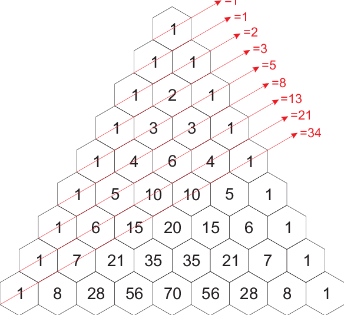

## One more slight of hand

Now let \(x = y = z\) (a domino is a domino is a domino – ignore orientation).

\[ \begin{align} T &= 1 + zT + z^2 T \end{align} \] So

\[ \begin{align} T &= \frac{1}{1 - z - z^2}\\ \end{align} \]

(Unfortunately, this is not a geometric series, so we have some work to do.)

## Geometric Series to the Rescue

We would like to write \[ \begin{align} T &= \frac{1}{1 - z - z^2} = \sum_{n=0}^\infty t_n z^n \\ \end{align} \] as

\[ \begin{align} T &= \frac{1}{1 - z - z^2} = \frac{A}{1 - \alpha z} + \frac{B}{1-\beta z}\\[5mm] & = A[1 + \alpha z + \alpha^2 z^2 + \cdots] + B[1 + \beta z + \beta^2 z^2 + \cdots]\\\\ \end{align} \] So \(t_n = A \alpha^n + B \beta^n\). We just need to determine \(\alpha\), \(\beta\), \(A\), and \(B\).

## Finding \(\alpha\), \(\beta\), \(A\), and \(B\)

\[ \begin{align} T &= \frac{1}{1 - z - z^2} = \frac{A}{1 - \alpha z} + \frac{B}{1-\beta z}\\[5mm] \end{align} \]

Denominator:

\[ \begin{align} 1 - z - z^2 & = 1 - (\alpha + \beta)z + \alpha\beta z^2 \\ 1 &= \alpha + \beta\\ -1 & = \alpha \beta \end{align} \]

Numerator: \[ \begin{align} 1 &= A (1 -\beta z) + B (1-\alpha z) = (A + B) - (A \beta + B \alpha) z \\ 1 &= A+B \\ 0 &= A\beta + B \alpha \end{align} \]

## Finding \(\alpha\), \(\beta\)

\[ \begin{align} \alpha + \beta & = 1 & \alpha \beta &= -1 \\ A + B &= 1 & A\beta + B \alpha &= 0 \end{align} \] From this we get

\[ \begin{align} -1 &= \alpha \beta = \alpha (1-\alpha) = \alpha - \alpha^2 & 0 & = \alpha^2 - \alpha - 1\\ \alpha &= \frac{1 + \sqrt{5}}{2} \approx 1.618 & \beta &= \frac{1 - \sqrt{5}}{2} \approx -0.618\\ \end{align} \]

Recall that \(t_n = A\alpha^n + B \beta^n\).

Since \(|\beta| < 1\), \(|\beta|^n \searrow 0\) as \(n \to \infty\), so we can basically ignore that part:

\[ \fbox{$t_n \approx A \alpha^n$} \]

## Finding \(A\) (and \(B\))

\[ \begin{align} \alpha + \beta & = 1 & \alpha \beta &= -1 \\ A + B &= 1 & A\beta + B \alpha &= 0 \\ \end{align} \] \[ \begin{align} 0 &= A \beta + (1-A) \alpha \\ 0 &= A \beta + \alpha - A \alpha \\ 0 &= A (\beta -\alpha) + \alpha \\ A &= \frac{\alpha}{\alpha - \beta} = \frac{\alpha}{\sqrt{5}}\\ B &= 1 - A = \frac{\alpha - \beta}{\alpha - \beta} - \frac{\alpha}{\alpha - \beta} = \frac{-\beta}{\sqrt{5}} \end{align} \]

## Putting it all together

\[ \begin{align} t_n &= A \alpha^n + B \beta^n = \frac{\alpha^{n+1}}{\sqrt{5}} - \frac{\beta^{n+1}}{\sqrt{5}} \\[5mm] t_n &\approx A \alpha^n = \frac{\alpha^{n+1}}{\sqrt{5}} \end{align} \]

## Computation

```r
t <- function(n) {
  alpha <- (1 + sqrt(5))/2
  beta  <- (1 - sqrt(5))/2
  A <-   alpha / sqrt(5)
  B <- - beta  / sqrt(5)
  A * alpha^n + B * beta^n
}

t(0:20)
```

```
 [1]     1     1     2     3     5     8    13    21    34    55    89
[12]   144   233   377   610   987  1597  2584  4181  6765 10946
```

## Table of Values

| n | t | A part | B part |
| --- | --- | --- | --- |
| 0 | 1 | 0.7236068 | 0.276393202 |
| 1 | 1 | 1.1708204 | -0.170820393 |
| 2 | 2 | 1.8944272 | 0.105572809 |
| 3 | 3 | 3.0652476 | -0.065247584 |
| 4 | 5 | 4.9596748 | 0.040325225 |
| 5 | 8 | 8.0249224 | -0.024922359 |
| 6 | 13 | 12.9845971 | 0.015402865 |
| 7 | 21 | 21.0095195 | -0.009519494 |
| 8 | 34 | 33.9941166 | 0.005883371 |
| 9 | 55 | 55.0036361 | -0.003636123 |
| 10 | 89 | 88.9977528 | 0.002247248 |

## Tiling 3 x n

## Fundamental Equation for U

[interactive chart not shown]

U = ??

## Fundamental Equation for U

[interactive chart not shown]

U = 1 +

[figure not shown]

U +

[figure not shown]

V +

[figure not shown]

Λ

## Fundamental Equations for U

[interactive chart not shown]

U = 1 +

[figure not shown]

U +

[figure not shown]

V +

[figure not shown]

Λ

V = +

[figure not shown]

U +

[figure not shown]

V

Λ = +

[figure not shown]

U +

[figure not shown]

Λ

## Algebra

We start with 3 equations and 3 unknowns, \(U\), \(V\), and \(\Lambda\).

\[ \begin{align} U &= 1 + z^3 U + z^2 V + z^2 \Lambda \\ V &= z U + z^3 V \\ \Lambda &= z U + z^3 \Lambda \\ \end{align} \]

We can use these to express \(V\) and \(\Lambda\) in terms of \(U\). \[ \begin{align} V &= (1 - z^3)^{-1} z U\\ \Lambda &= (1 - z^3)^{-1} z U\\ \end{align} \]

Plugging these in, we now have just one equation with one unknown.

\[ \begin{align} U &= 1 + z^3 U + z^2 (1 - z^3)^{-1} z U + z^2 (1 - z^3)^{-1} z U \end{align} \]

## Solving for \(U\)

\[ \begin{align} U &= 1 + z^3 U + z^2 (1 - z^3)^{-1} z U + z^2 (1 - z^3)^{-1} z U \end{align} \]

\[ \begin{align} 1 &= U - z^3 U - z^2 (1 - z^3)^{-1} z U - z^2 (1 - z^3)^{-1} z U \\ 1 &= \left[1 - z^3 - z^2 (1 - z^3)^{-1} z - z^2 (1 - z^3)^{-1} z\right] U \\ U &= \frac{1}{\left[(1 - z^3) - z^2 (1 - z^3)^{-1} z - z^2 (1 - z^3)^{-1} z\right]} \\ U &= \frac{1 - z^3}{\left[(1 - z^3)^2 - 2z^3\right]} \\ \end{align} \]

## Let \(w = z^3\) (dominoes come in threes)

\[ \begin{align} U &= \frac{1 - z^3}{\left[(1 - z^3)^2 - 2z^3\right]} = \frac{1 - w}{\left[(1 - w)^2 - 2w\right]} \\ &= \frac{1 - w}{\left[1 -2w + w^2 - 2w\right]} \\ &= \frac{1 - w}{\left[1 - 4w + w^2 \right]} \\ & = \frac{A}{1 - \alpha w} + \frac{B}{1-\beta w}\\ & = A[1 + \alpha w + \alpha^2 w^2 + \cdots] + B[1 + \beta w + \beta^2 w^2 + \cdots]\\\ &= \sum A \alpha^n w^n + B \beta^n w^n \end{align} \]

## Same story as before (but different constants)

\[ \begin{align} u_n &= A \alpha^n + B \beta^n \\ & = \mbox{number of ways to tile $3 \times 2n$ with $3n$ dominoes} \end{align} \]

We just need to determine \(\alpha\), \(\beta\), \(A\), and \(B\).

Using algebra similar to the \(2 \times n\) case, we get

\[ \begin{align} \alpha &= 2 + \sqrt{3} & \beta &= 2 - \sqrt{3} \\ A &= \frac{1}{2} + \frac{\sqrt{3}}{6} & B &= \frac{1}{2} - \frac{\sqrt{3}}{6}\\ \end{align} \]

## Computation

```r
u <- function(n) {
  alpha <- 2 + sqrt(3)
  beta  <- 2 - sqrt(3)
  A <-   1/2 + sqrt(3) / 6
  B <-   1/2 - sqrt(3) / 6
  A * alpha^n + B * beta^n
}
u(0:20)
```

```
 [1]            1            3           11           41          153
 [6]          571         2131         7953        29681       110771
[11]       413403      1542841      5757961     21489003     80198051
[16]    299303201   1117014753   4168755811  15558008491  58063278153
[21] 216695104121
```

## Table of Values

| n | t | u | A part | B part |
| --- | --- | --- | --- | --- |
| 0 | 1 | 1 | 0.7886751 | 0.2113248654051871345 |
| 1 | 1 | 3 | 2.9433757 | 0.0566243270259356168 |
| 2 | 2 | 11 | 10.9848276 | 0.0151724426985552496 |
| 3 | 3 | 41 | 40.9959346 | 0.0040654437682853643 |
| 4 | 5 | 153 | 152.9989107 | 0.0010893323745862042 |
| 5 | 8 | 571 | 570.9997081 | 0.0002918857300594508 |
| 6 | 13 | 2131 | 2130.9999218 | 0.0000782105456515985 |
| 7 | 21 | 7953 | 7952.9999790 | 0.0000209564525469433 |
| 8 | 34 | 29681 | 29680.9999944 | 0.0000056152645361746 |
| 9 | 55 | 110771 | 110770.9999985 | 0.0000015046055977551 |
| 10 | 89 | 413403 | 413402.9999996 | 0.0000004031578548458 |
| 11 | 144 | 1542841 | 1542840.9999999 | 0.0000001080258216282 |
| 12 | 233 | 5757961 | 5757961.0000000 | 0.0000000289454316670 |
| 13 | 377 | 21489003 | 21489003.0000000 | 0.0000000077559050397 |
| 14 | 610 | 80198051 | 80198051.0000000 | 0.0000000020781884920 |
| 15 | 987 | 299303201 | 299303200.9999999 | 0.0000000005568489281 |
| 16 | 1597 | 1117014753 | 1117014752.9999995 | 0.0000000001492072206 |
| 17 | 2584 | 4168755811 | 4168755810.9999976 | 0.0000000000399799543 |
| 18 | 4181 | 15558008491 | 15558008490.9999905 | 0.0000000000107125965 |
| 19 | 6765 | 58063278153 | 58063278152.9999771 | 0.0000000000028704316 |
| 20 | 10946 | 216695104121 | 216695104120.9998779 | 0.0000000000007691298 |

## Want to Know More?

[figure not shown]

## Some Images

1 + T +

T = 1 / (1 - -

[interactive chart not shown]